# Risk Factor Analysis

## Outcome Variable

**Outcome Variable:** ever_stunted

## Predictor Variables

**Intervention Variable:** fhtcm

**Adjustment Set:**

- arm
- W_mage
- W_fage
- meducyrs
- feducyrs
- W_mhtcm
- W_mwtkg
- W_mbmi
- single
- delta_W_mage
- delta_W_fage
- delta_meducyrs
- delta_feducyrs
- delta_W_mhtcm
- delta_W_mwtkg
- delta_W_mbmi
- delta_single

## Stratifying Variables

The analysis was stratified on these variable(s):

- agecat
- studyid
- country

## Data Summary

| agecat | studyid | country | fhtcm | ever_stunted | n_cell | n |
| --- | --- | --- | --- | --- | --- | --- |
| 0-6 months | ki1000304b-SAS-CompFeed | INDIA | [160-170) | 0 | 368 | 905 |
| 0-6 months | ki1000304b-SAS-CompFeed | INDIA | [160-170) | 1 | 149 | 905 |
| 0-6 months | ki1000304b-SAS-CompFeed | INDIA | <160 | 0 | 81 | 905 |
| 0-6 months | ki1000304b-SAS-CompFeed | INDIA | <160 | 1 | 54 | 905 |
| 0-6 months | ki1000304b-SAS-CompFeed | INDIA | >=170 | 0 | 194 | 905 |
| 0-6 months | ki1000304b-SAS-CompFeed | INDIA | >=170 | 1 | 59 | 905 |
| 0-6 months | ki1000304b-SAS-FoodSuppl | INDIA | [160-170) | 0 | 148 | 397 |
| 0-6 months | ki1000304b-SAS-FoodSuppl | INDIA | [160-170) | 1 | 91 | 397 |
| 0-6 months | ki1000304b-SAS-FoodSuppl | INDIA | <160 | 0 | 55 | 397 |
| 0-6 months | ki1000304b-SAS-FoodSuppl | INDIA | <160 | 1 | 48 | 397 |
| 0-6 months | ki1000304b-SAS-FoodSuppl | INDIA | >=170 | 0 | 42 | 397 |
| 0-6 months | ki1000304b-SAS-FoodSuppl | INDIA | >=170 | 1 | 13 | 397 |
| 0-6 months | ki1101329-Keneba | GAMBIA | [160-170) | 0 | 851 | 1723 |
| 0-6 months | ki1101329-Keneba | GAMBIA | [160-170) | 1 | 86 | 1723 |
| 0-6 months | ki1101329-Keneba | GAMBIA | <160 | 0 | 32 | 1723 |
| 0-6 months | ki1101329-Keneba | GAMBIA | <160 | 1 | 6 | 1723 |
| 0-6 months | ki1101329-Keneba | GAMBIA | >=170 | 0 | 697 | 1723 |
| 0-6 months | ki1101329-Keneba | GAMBIA | >=170 | 1 | 51 | 1723 |
| 0-6 months | ki1119695-PROBIT | BELARUS | [160-170) | 0 | 1384 | 12537 |
| 0-6 months | ki1119695-PROBIT | BELARUS | [160-170) | 1 | 3 | 12537 |
| 0-6 months | ki1119695-PROBIT | BELARUS | <160 | 0 | 54 | 12537 |
| 0-6 months | ki1119695-PROBIT | BELARUS | <160 | 1 | 0 | 12537 |
| 0-6 months | ki1119695-PROBIT | BELARUS | >=170 | 0 | 11070 | 12537 |
| 0-6 months | ki1119695-PROBIT | BELARUS | >=170 | 1 | 26 | 12537 |
| 0-6 months | ki1135781-COHORTS | GUATEMALA | [160-170) | 0 | 132 | 337 |
| 0-6 months | ki1135781-COHORTS | GUATEMALA | [160-170) | 1 | 29 | 337 |
| 0-6 months | ki1135781-COHORTS | GUATEMALA | <160 | 0 | 115 | 337 |
| 0-6 months | ki1135781-COHORTS | GUATEMALA | <160 | 1 | 35 | 337 |
| 0-6 months | ki1135781-COHORTS | GUATEMALA | >=170 | 0 | 22 | 337 |
| 0-6 months | ki1135781-COHORTS | GUATEMALA | >=170 | 1 | 4 | 337 |

[output cut: 60 more lines]

The following strata were considered:

- agecat: 0-24 months, studyid: ki1000304b-SAS-CompFeed, country: INDIA
- agecat: 0-24 months, studyid: ki1000304b-SAS-FoodSuppl, country: INDIA
- agecat: 0-24 months, studyid: ki1101329-Keneba, country: GAMBIA
- agecat: 0-24 months, studyid: ki1119695-PROBIT, country: BELARUS
- agecat: 0-24 months, studyid: ki1135781-COHORTS, country: GUATEMALA
- agecat: 0-6 months, studyid: ki1000304b-SAS-CompFeed, country: INDIA
- agecat: 0-6 months, studyid: ki1000304b-SAS-FoodSuppl, country: INDIA
- agecat: 0-6 months, studyid: ki1101329-Keneba, country: GAMBIA
- agecat: 0-6 months, studyid: ki1119695-PROBIT, country: BELARUS
- agecat: 0-6 months, studyid: ki1135781-COHORTS, country: GUATEMALA
- agecat: 6-24 months, studyid: ki1000304b-SAS-CompFeed, country: INDIA
- agecat: 6-24 months, studyid: ki1000304b-SAS-FoodSuppl, country: INDIA
- agecat: 6-24 months, studyid: ki1101329-Keneba, country: GAMBIA
- agecat: 6-24 months, studyid: ki1119695-PROBIT, country: BELARUS
- agecat: 6-24 months, studyid: ki1135781-COHORTS, country: GUATEMALA

### Dropped Strata

Some strata were dropped due to rare outcomes:

- agecat: 0-6 months, studyid: ki1119695-PROBIT, country: BELARUS
- agecat: 0-6 months, studyid: ki1135781-COHORTS, country: GUATEMALA

## Methods Detail

We’re interested in the causal parameters $E[Y_a]$ for all values of $a \in \mathcal{A}$. These parameters represent the mean outcome if, possibly contrary to fact, we intervened to set all units to have $A=a$. Under the randomization and positivity assumptions, these are identified by the statistical parameters $\psi_a=E_W[E_{Y|A,W}(Y|A=a,W)]$. In addition, we’re interested in the mean of $Y$, $E[Y]$ under no intervention (the observed mean). We will estimate these parameters by using SuperLearner to fit the relevant likelihood factors – $E_{Y|A,W}(Y|A=a,W)$ and $p(A=a|W)$, and then updating our likelihood fit using a joint TMLE.

For unadjusted analyses ($W=\{\}$), initial likelihoods were estimated using Lrnr_glm to estimate the simple $E(Y|A)$ and Lrnr_mean to estimate $p(A)$. For adjusted analyses, a small library containing Lrnr_glmnet, Lrnr_xgboost, and Lrnr_mean was used.

Having estimated these parameters, we will then use the delta method to estimate relative risks and attributable risks relative to a prespecified baseline level of $A$.

# Results Detail

## Results Plots

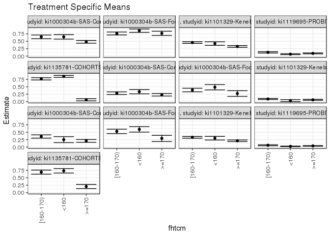

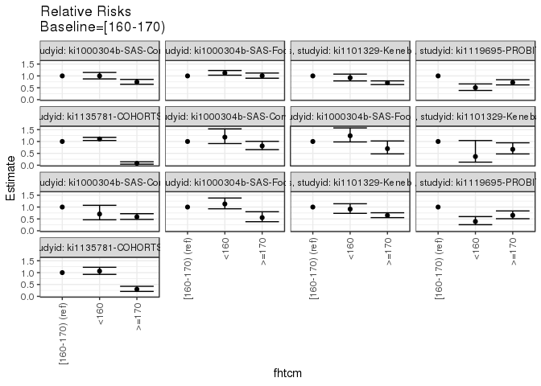

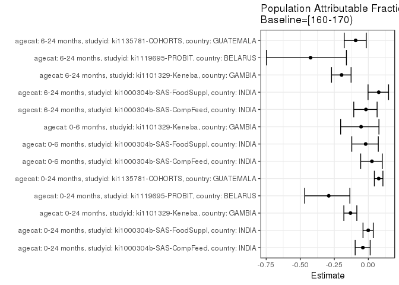

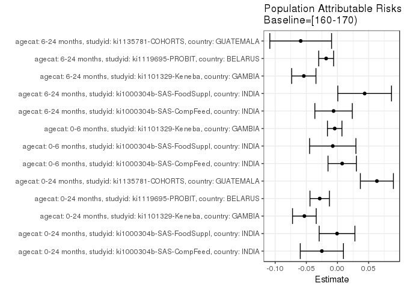

## Results Table

### Parameter: TSM

| agecat | studyid | country | intervention_level | baseline_level | estimate | ci_lower | ci_upper |
| --- | --- | --- | --- | --- | --- | --- | --- |
| 0-24 months | ki1000304b-SAS-CompFeed | INDIA | [160-170) | NA | 0.6479907 | 0.5858700 | 0.7101113 |
| 0-24 months | ki1000304b-SAS-CompFeed | INDIA | <160 | NA | 0.6482416 | 0.5724685 | 0.7240148 |
| 0-24 months | ki1000304b-SAS-CompFeed | INDIA | >=170 | NA | 0.4811219 | 0.4356053 | 0.5266385 |
| 0-24 months | ki1000304b-SAS-FoodSuppl | INDIA | [160-170) | NA | 0.7625766 | 0.7130016 | 0.8121517 |
| 0-24 months | ki1000304b-SAS-FoodSuppl | INDIA | <160 | NA | 0.8581025 | 0.8026666 | 0.9135385 |
| 0-24 months | ki1000304b-SAS-FoodSuppl | INDIA | >=170 | NA | 0.7673339 | 0.6954130 | 0.8392548 |
| 0-24 months | ki1101329-Keneba | GAMBIA | [160-170) | NA | 0.4579860 | 0.4292885 | 0.4866835 |
| 0-24 months | ki1101329-Keneba | GAMBIA | <160 | NA | 0.4220957 | 0.3623235 | 0.4818678 |
| 0-24 months | ki1101329-Keneba | GAMBIA | >=170 | NA | 0.3244637 | 0.2947484 | 0.3541789 |
| 0-24 months | ki1119695-PROBIT | BELARUS | [160-170) | NA | 0.1265354 | 0.1039196 | 0.1491512 |
| 0-24 months | ki1119695-PROBIT | BELARUS | <160 | NA | 0.0639704 | 0.0513126 | 0.0766282 |
| 0-24 months | ki1119695-PROBIT | BELARUS | >=170 | NA | 0.0913704 | 0.0761709 | 0.1065699 |
| 0-24 months | ki1135781-COHORTS | GUATEMALA | [160-170) | NA | 0.7693703 | 0.7313436 | 0.8073970 |
| 0-24 months | ki1135781-COHORTS | GUATEMALA | <160 | NA | 0.8513150 | 0.8179343 | 0.8846958 |
| 0-24 months | ki1135781-COHORTS | GUATEMALA | >=170 | NA | 0.0608758 | 0.0245478 | 0.0972038 |
| 0-6 months | ki1000304b-SAS-CompFeed | INDIA | [160-170) | NA | 0.2819381 | 0.2360868 | 0.3277894 |
| 0-6 months | ki1000304b-SAS-CompFeed | INDIA | <160 | NA | 0.3334644 | 0.2617694 | 0.4051594 |
| 0-6 months | ki1000304b-SAS-CompFeed | INDIA | >=170 | NA | 0.2290446 | 0.1866022 | 0.2714869 |
| 0-6 months | ki1000304b-SAS-FoodSuppl | INDIA | [160-170) | NA | 0.3904169 | 0.3306708 | 0.4501630 |
| 0-6 months | ki1000304b-SAS-FoodSuppl | INDIA | <160 | NA | 0.4847163 | 0.3954134 | 0.5740192 |
| 0-6 months | ki1000304b-SAS-FoodSuppl | INDIA | >=170 | NA | 0.2723113 | 0.1761622 | 0.3684604 |
| 0-6 months | ki1101329-Keneba | GAMBIA | [160-170) | NA | 0.0874316 | 0.0695401 | 0.1053232 |
| 0-6 months | ki1101329-Keneba | GAMBIA | <160 | NA | 0.0319616 | -0.0008160 | 0.0647392 |
| 0-6 months | ki1101329-Keneba | GAMBIA | >=170 | NA | 0.0585008 | 0.0422787 | 0.0747229 |
| 6-24 months | ki1000304b-SAS-CompFeed | INDIA | [160-170) | NA | 0.3572175 | 0.3021068 | 0.4123283 |
| 6-24 months | ki1000304b-SAS-CompFeed | INDIA | <160 | NA | 0.2518606 | 0.1521445 | 0.3515766 |
| 6-24 months | ki1000304b-SAS-CompFeed | INDIA | >=170 | NA | 0.2097512 | 0.1608601 | 0.2586423 |
| 6-24 months | ki1000304b-SAS-FoodSuppl | INDIA | [160-170) | NA | 0.5290970 | 0.4532343 | 0.6049597 |
| 6-24 months | ki1000304b-SAS-FoodSuppl | INDIA | <160 | NA | 0.5986300 | 0.5068298 | 0.6904302 |
| 6-24 months | ki1000304b-SAS-FoodSuppl | INDIA | >=170 | NA | 0.2931825 | 0.1897195 | 0.3966454 |
| 6-24 months | ki1101329-Keneba | GAMBIA | [160-170) | NA | 0.3289235 | 0.2989683 | 0.3588787 |
| 6-24 months | ki1101329-Keneba | GAMBIA | <160 | NA | 0.3008429 | 0.2402334 | 0.3614524 |
| 6-24 months | ki1101329-Keneba | GAMBIA | >=170 | NA | 0.2132376 | 0.1852749 | 0.2412004 |
| 6-24 months | ki1119695-PROBIT | BELARUS | [160-170) | NA | 0.0609237 | 0.0447539 | 0.0770934 |
| 6-24 months | ki1119695-PROBIT | BELARUS | <160 | NA | 0.0238546 | 0.0140012 | 0.0337080 |
| 6-24 months | ki1119695-PROBIT | BELARUS | >=170 | NA | 0.0397594 | 0.0301024 | 0.0494164 |
| 6-24 months | ki1135781-COHORTS | GUATEMALA | [160-170) | NA | 0.6907980 | 0.6208728 | 0.7607231 |
| 6-24 months | ki1135781-COHORTS | GUATEMALA | <160 | NA | 0.7358600 | 0.6602027 | 0.8115173 |
| 6-24 months | ki1135781-COHORTS | GUATEMALA | >=170 | NA | 0.2047532 | 0.1348523 | 0.2746542 |

### Parameter: E(Y)

| agecat | studyid | country | intervention_level | baseline_level | estimate | ci_lower | ci_upper |
| --- | --- | --- | --- | --- | --- | --- | --- |
| 0-24 months | ki1000304b-SAS-CompFeed | INDIA | NA | NA | 0.6229327 | 0.5785357 | 0.6673298 |
| 0-24 months | ki1000304b-SAS-FoodSuppl | INDIA | NA | NA | 0.7619048 | 0.7200609 | 0.8037487 |
| 0-24 months | ki1101329-Keneba | GAMBIA | NA | NA | 0.4048730 | 0.3829622 | 0.4267838 |
| 0-24 months | ki1119695-PROBIT | BELARUS | NA | NA | 0.0980298 | 0.0820346 | 0.1140250 |
| 0-24 months | ki1135781-COHORTS | GUATEMALA | NA | NA | 0.8326613 | 0.7997778 | 0.8655448 |
| 0-6 months | ki1000304b-SAS-CompFeed | INDIA | NA | NA | 0.2895028 | 0.2525193 | 0.3264862 |
| 0-6 months | ki1000304b-SAS-FoodSuppl | INDIA | NA | NA | 0.3828715 | 0.3349959 | 0.4307472 |
| 0-6 months | ki1101329-Keneba | GAMBIA | NA | NA | 0.0829948 | 0.0699648 | 0.0960247 |
| 6-24 months | ki1000304b-SAS-CompFeed | INDIA | NA | NA | 0.3509700 | 0.3057207 | 0.3962194 |
| 6-24 months | ki1000304b-SAS-FoodSuppl | INDIA | NA | NA | 0.5727273 | 0.5072105 | 0.6382441 |
| 6-24 months | ki1101329-Keneba | GAMBIA | NA | NA | 0.2749226 | 0.2531408 | 0.2967044 |
| 6-24 months | ki1119695-PROBIT | BELARUS | NA | NA | 0.0427669 | 0.0325915 | 0.0529422 |
| 6-24 months | ki1135781-COHORTS | GUATEMALA | NA | NA | 0.6317992 | 0.5705230 | 0.6930753 |

### Parameter: RR

| agecat | studyid | country | intervention_level | baseline_level | estimate | ci_lower | ci_upper |
| --- | --- | --- | --- | --- | --- | --- | --- |
| 0-24 months | ki1000304b-SAS-CompFeed | INDIA | [160-170) | [160-170) | 1.0000000 | 1.0000000 | 1.0000000 |
| 0-24 months | ki1000304b-SAS-CompFeed | INDIA | <160 | [160-170) | 1.0003873 | 0.8737562 | 1.1453708 |
| 0-24 months | ki1000304b-SAS-CompFeed | INDIA | >=170 | [160-170) | 0.7424828 | 0.6469819 | 0.8520806 |
| 0-24 months | ki1000304b-SAS-FoodSuppl | INDIA | [160-170) | [160-170) | 1.0000000 | 1.0000000 | 1.0000000 |
| 0-24 months | ki1000304b-SAS-FoodSuppl | INDIA | <160 | [160-170) | 1.1252673 | 1.0304595 | 1.2287980 |
| 0-24 months | ki1000304b-SAS-FoodSuppl | INDIA | >=170 | [160-170) | 1.0062384 | 0.9027340 | 1.1216104 |
| 0-24 months | ki1101329-Keneba | GAMBIA | [160-170) | [160-170) | 1.0000000 | 1.0000000 | 1.0000000 |
| 0-24 months | ki1101329-Keneba | GAMBIA | <160 | [160-170) | 0.9216345 | 0.7900295 | 1.0751626 |
| 0-24 months | ki1101329-Keneba | GAMBIA | >=170 | [160-170) | 0.7084576 | 0.6351314 | 0.7902493 |
| 0-24 months | ki1119695-PROBIT | BELARUS | [160-170) | [160-170) | 1.0000000 | 1.0000000 | 1.0000000 |
| 0-24 months | ki1119695-PROBIT | BELARUS | <160 | [160-170) | 0.5055536 | 0.3863098 | 0.6616048 |
| 0-24 months | ki1119695-PROBIT | BELARUS | >=170 | [160-170) | 0.7220937 | 0.6216355 | 0.8387864 |
| 0-24 months | ki1135781-COHORTS | GUATEMALA | [160-170) | [160-170) | 1.0000000 | 1.0000000 | 1.0000000 |
| 0-24 months | ki1135781-COHORTS | GUATEMALA | <160 | [160-170) | 1.1065088 | 1.0424659 | 1.1744861 |
| 0-24 months | ki1135781-COHORTS | GUATEMALA | >=170 | [160-170) | 0.0791242 | 0.0434864 | 0.1439677 |
| 0-6 months | ki1000304b-SAS-CompFeed | INDIA | [160-170) | [160-170) | 1.0000000 | 1.0000000 | 1.0000000 |
| 0-6 months | ki1000304b-SAS-CompFeed | INDIA | <160 | [160-170) | 1.1827575 | 0.9131927 | 1.5318950 |
| 0-6 months | ki1000304b-SAS-CompFeed | INDIA | >=170 | [160-170) | 0.8123930 | 0.6563481 | 1.0055372 |
| 0-6 months | ki1000304b-SAS-FoodSuppl | INDIA | [160-170) | [160-170) | 1.0000000 | 1.0000000 | 1.0000000 |
| 0-6 months | ki1000304b-SAS-FoodSuppl | INDIA | <160 | [160-170) | 1.2415350 | 0.9809977 | 1.5712667 |
| 0-6 months | ki1000304b-SAS-FoodSuppl | INDIA | >=170 | [160-170) | 0.6974885 | 0.4763888 | 1.0212043 |
| 0-6 months | ki1101329-Keneba | GAMBIA | [160-170) | [160-170) | 1.0000000 | 1.0000000 | 1.0000000 |
| 0-6 months | ki1101329-Keneba | GAMBIA | <160 | [160-170) | 0.3655614 | 0.1284296 | 1.0405324 |
| 0-6 months | ki1101329-Keneba | GAMBIA | >=170 | [160-170) | 0.6691033 | 0.4741534 | 0.9442078 |
| 6-24 months | ki1000304b-SAS-CompFeed | INDIA | [160-170) | [160-170) | 1.0000000 | 1.0000000 | 1.0000000 |
| 6-24 months | ki1000304b-SAS-CompFeed | INDIA | <160 | [160-170) | 0.7050621 | 0.4634606 | 1.0726102 |
| 6-24 months | ki1000304b-SAS-CompFeed | INDIA | >=170 | [160-170) | 0.5871805 | 0.4787460 | 0.7201751 |
| 6-24 months | ki1000304b-SAS-FoodSuppl | INDIA | [160-170) | [160-170) | 1.0000000 | 1.0000000 | 1.0000000 |
| 6-24 months | ki1000304b-SAS-FoodSuppl | INDIA | <160 | [160-170) | 1.1314183 | 0.9265674 | 1.3815587 |
| 6-24 months | ki1000304b-SAS-FoodSuppl | INDIA | >=170 | [160-170) | 0.5541186 | 0.3824636 | 0.8028145 |
| 6-24 months | ki1101329-Keneba | GAMBIA | [160-170) | [160-170) | 1.0000000 | 1.0000000 | 1.0000000 |
| 6-24 months | ki1101329-Keneba | GAMBIA | <160 | [160-170) | 0.9146287 | 0.7339557 | 1.1397769 |
| 6-24 months | ki1101329-Keneba | GAMBIA | >=170 | [160-170) | 0.6482894 | 0.5534541 | 0.7593748 |
| 6-24 months | ki1119695-PROBIT | BELARUS | [160-170) | [160-170) | 1.0000000 | 1.0000000 | 1.0000000 |
| 6-24 months | ki1119695-PROBIT | BELARUS | <160 | [160-170) | 0.3915486 | 0.2564544 | 0.5978073 |
| 6-24 months | ki1119695-PROBIT | BELARUS | >=170 | [160-170) | 0.6526101 | 0.5092703 | 0.8362946 |
| 6-24 months | ki1135781-COHORTS | GUATEMALA | [160-170) | [160-170) | 1.0000000 | 1.0000000 | 1.0000000 |
| 6-24 months | ki1135781-COHORTS | GUATEMALA | <160 | [160-170) | 1.0652318 | 0.9258290 | 1.2256246 |
| 6-24 months | ki1135781-COHORTS | GUATEMALA | >=170 | [160-170) | 0.2964010 | 0.2080843 | 0.4222018 |

### Parameter: PAR

| agecat | studyid | country | intervention_level | baseline_level | estimate | ci_lower | ci_upper |
| --- | --- | --- | --- | --- | --- | --- | --- |
| 0-24 months | ki1000304b-SAS-CompFeed | INDIA | [160-170) | NA | -0.0250579 | -0.0597139 | 0.0095980 |
| 0-24 months | ki1000304b-SAS-FoodSuppl | INDIA | [160-170) | NA | -0.0006719 | -0.0293513 | 0.0280076 |
| 0-24 months | ki1101329-Keneba | GAMBIA | [160-170) | NA | -0.0531130 | -0.0721187 | -0.0341073 |
| 0-24 months | ki1119695-PROBIT | BELARUS | [160-170) | NA | -0.0285055 | -0.0441311 | -0.0128800 |
| 0-24 months | ki1135781-COHORTS | GUATEMALA | [160-170) | NA | 0.0632909 | 0.0367706 | 0.0898113 |
| 0-6 months | ki1000304b-SAS-CompFeed | INDIA | [160-170) | NA | 0.0075647 | -0.0151773 | 0.0303066 |
| 0-6 months | ki1000304b-SAS-FoodSuppl | INDIA | [160-170) | NA | -0.0075454 | -0.0447064 | 0.0296156 |
| 0-6 months | ki1101329-Keneba | GAMBIA | [160-170) | NA | -0.0044369 | -0.0160819 | 0.0072082 |
| 6-24 months | ki1000304b-SAS-CompFeed | INDIA | [160-170) | NA | -0.0062475 | -0.0362948 | 0.0237998 |
| 6-24 months | ki1000304b-SAS-FoodSuppl | INDIA | [160-170) | NA | 0.0436303 | 0.0005346 | 0.0867260 |
| 6-24 months | ki1101329-Keneba | GAMBIA | [160-170) | NA | -0.0540009 | -0.0734902 | -0.0345116 |
| 6-24 months | ki1119695-PROBIT | BELARUS | [160-170) | NA | -0.0181568 | -0.0301138 | -0.0061997 |
| 6-24 months | ki1135781-COHORTS | GUATEMALA | [160-170) | NA | -0.0589988 | -0.1085588 | -0.0094389 |

### Parameter: PAF

| agecat | studyid | country | intervention_level | baseline_level | estimate | ci_lower | ci_upper |
| --- | --- | --- | --- | --- | --- | --- | --- |
| 0-24 months | ki1000304b-SAS-CompFeed | INDIA | [160-170) | NA | -0.0402257 | -0.0967738 | 0.0134069 |
| 0-24 months | ki1000304b-SAS-FoodSuppl | INDIA | [160-170) | NA | -0.0008818 | -0.0392428 | 0.0360632 |
| 0-24 months | ki1101329-Keneba | GAMBIA | [160-170) | NA | -0.1311844 | -0.1798268 | -0.0845473 |
| 0-24 months | ki1119695-PROBIT | BELARUS | [160-170) | NA | -0.2907844 | -0.4670911 | -0.1356653 |
| 0-24 months | ki1135781-COHORTS | GUATEMALA | [160-170) | NA | 0.0760104 | 0.0440650 | 0.1068883 |
| 0-6 months | ki1000304b-SAS-CompFeed | INDIA | [160-170) | NA | 0.0261298 | -0.0562236 | 0.1020621 |
| 0-6 months | ki1000304b-SAS-FoodSuppl | INDIA | [160-170) | NA | -0.0197074 | -0.1216483 | 0.0729687 |
| 0-6 months | ki1101329-Keneba | GAMBIA | [160-170) | NA | -0.0534596 | -0.2033643 | 0.0777713 |
| 6-24 months | ki1000304b-SAS-CompFeed | INDIA | [160-170) | NA | -0.0178007 | -0.1070703 | 0.0642705 |
| 6-24 months | ki1000304b-SAS-FoodSuppl | INDIA | [160-170) | NA | 0.0761798 | -0.0021029 | 0.1483472 |
| 6-24 months | ki1101329-Keneba | GAMBIA | [160-170) | NA | -0.1964222 | -0.2704243 | -0.1267307 |
| 6-24 months | ki1119695-PROBIT | BELARUS | [160-170) | NA | -0.4245521 | -0.7478698 | -0.1610411 |
| 6-24 months | ki1135781-COHORTS | GUATEMALA | [160-170) | NA | -0.0933822 | -0.1773476 | -0.0154050 |